# Risk Factor Analysis

## Outcome Variable

**Outcome Variable:** haz

## Predictor Variables

**Intervention Variable:** predfeed3

**Adjustment Set:**

- arm
- sex
- month
- brthmon
- W_mage
- meducyrs
- feducyrs
- hhwealth_quart
- hfoodsec
- W_mhtcm
- W_mwtkg
- W_mbmi
- vagbrth
- W_gagebrth
- W_birthwt
- W_birthlen
- W_nrooms
- W_nchldlt5
- W_parity
- impfloor
- impsan
- safeh20
- delta_W_mage
- delta_meducyrs
- delta_feducyrs
- delta_hhwealth_quart
- delta_hfoodsec
- delta_W_mhtcm
- delta_W_mwtkg
- delta_W_mbmi
- delta_vagbrth
- delta_W_gagebrth
- delta_W_birthwt
- delta_W_birthlen
- delta_W_nrooms
- delta_W_nchldlt5
- delta_W_parity
- delta_impfloor
- delta_impsan
- delta_safeh20

## Stratifying Variables

The analysis was stratified on these variable(s):

- agecat
- studyid
- country

## Data Summary

| agecat | studyid | country | predfeed3 | n_cell | n |
| --- | --- | --- | --- | --- | --- |
| Birth | ki0047075b-MAL-ED | BANGLADESH | 1 | 176 | 215 |
| Birth | ki0047075b-MAL-ED | BANGLADESH | 0 | 39 | 215 |
| Birth | ki0047075b-MAL-ED | BRAZIL | 1 | 24 | 57 |
| Birth | ki0047075b-MAL-ED | BRAZIL | 0 | 33 | 57 |
| Birth | ki0047075b-MAL-ED | INDIA | 1 | 29 | 41 |
| Birth | ki0047075b-MAL-ED | INDIA | 0 | 12 | 41 |
| Birth | ki0047075b-MAL-ED | NEPAL | 1 | 14 | 26 |
| Birth | ki0047075b-MAL-ED | NEPAL | 0 | 12 | 26 |
| Birth | ki0047075b-MAL-ED | PERU | 1 | 150 | 223 |
| Birth | ki0047075b-MAL-ED | PERU | 0 | 73 | 223 |
| Birth | ki0047075b-MAL-ED | SOUTH AFRICA | 1 | 33 | 100 |
| Birth | ki0047075b-MAL-ED | SOUTH AFRICA | 0 | 67 | 100 |
| Birth | ki0047075b-MAL-ED | TANZANIA, UNITED REPUBLIC OF | 1 | 26 | 102 |
| Birth | ki0047075b-MAL-ED | TANZANIA, UNITED REPUBLIC OF | 0 | 76 | 102 |
| Birth | ki1000109-EE | PAKISTAN | 1 | 35 | 35 |
| Birth | ki1000109-EE | PAKISTAN | 0 | 0 | 35 |
| Birth | ki1113344-GMS-Nepal | NEPAL | 1 | 380 | 458 |
| Birth | ki1113344-GMS-Nepal | NEPAL | 0 | 78 | 458 |
| Birth | kiGH5241-JiVitA-3 | BANGLADESH | 1 | 13482 | 14888 |
| Birth | kiGH5241-JiVitA-3 | BANGLADESH | 0 | 1406 | 14888 |
| Birth | kiGH5241-JiVitA-4 | BANGLADESH | 1 | 105 | 116 |
| Birth | kiGH5241-JiVitA-4 | BANGLADESH | 0 | 11 | 116 |
| 6 months | ki0047075b-MAL-ED | BANGLADESH | 1 | 191 | 233 |
| 6 months | ki0047075b-MAL-ED | BANGLADESH | 0 | 42 | 233 |
| 6 months | ki0047075b-MAL-ED | BRAZIL | 1 | 93 | 187 |
| 6 months | ki0047075b-MAL-ED | BRAZIL | 0 | 94 | 187 |
| 6 months | ki0047075b-MAL-ED | INDIA | 1 | 147 | 210 |
| 6 months | ki0047075b-MAL-ED | INDIA | 0 | 63 | 210 |
| 6 months | ki0047075b-MAL-ED | NEPAL | 1 | 113 | 227 |
| 6 months | ki0047075b-MAL-ED | NEPAL | 0 | 114 | 227 |
| 6 months | ki0047075b-MAL-ED | PERU | 1 | 176 | 270 |
| 6 months | ki0047075b-MAL-ED | PERU | 0 | 94 | 270 |
| 6 months | ki0047075b-MAL-ED | SOUTH AFRICA | 1 | 63 | 244 |
| 6 months | ki0047075b-MAL-ED | SOUTH AFRICA | 0 | 181 | 244 |
| 6 months | ki0047075b-MAL-ED | TANZANIA, UNITED REPUBLIC OF | 1 | 64 | 212 |
| 6 months | ki0047075b-MAL-ED | TANZANIA, UNITED REPUBLIC OF | 0 | 148 | 212 |
| 6 months | ki1000109-EE | PAKISTAN | 1 | 39 | 39 |
| 6 months | ki1000109-EE | PAKISTAN | 0 | 0 | 39 |
| 6 months | ki1113344-GMS-Nepal | NEPAL | 1 | 367 | 441 |
| 6 months | ki1113344-GMS-Nepal | NEPAL | 0 | 74 | 441 |
| 6 months | kiGH5241-JiVitA-3 | BANGLADESH | 1 | 8497 | 9307 |
| 6 months | kiGH5241-JiVitA-3 | BANGLADESH | 0 | 810 | 9307 |
| 6 months | kiGH5241-JiVitA-4 | BANGLADESH | 1 | 76 | 88 |
| 6 months | kiGH5241-JiVitA-4 | BANGLADESH | 0 | 12 | 88 |
| 24 months | ki0047075b-MAL-ED | BANGLADESH | 1 | 168 | 205 |
| 24 months | ki0047075b-MAL-ED | BANGLADESH | 0 | 37 | 205 |
| 24 months | ki0047075b-MAL-ED | BRAZIL | 1 | 79 | 152 |
| 24 months | ki0047075b-MAL-ED | BRAZIL | 0 | 73 | 152 |
| 24 months | ki0047075b-MAL-ED | INDIA | 1 | 139 | 202 |
| 24 months | ki0047075b-MAL-ED | INDIA | 0 | 63 | 202 |
| 24 months | ki0047075b-MAL-ED | NEPAL | 1 | 110 | 220 |
| 24 months | ki0047075b-MAL-ED | NEPAL | 0 | 110 | 220 |
| 24 months | ki0047075b-MAL-ED | PERU | 1 | 131 | 198 |
| 24 months | ki0047075b-MAL-ED | PERU | 0 | 67 | 198 |
| 24 months | ki0047075b-MAL-ED | SOUTH AFRICA | 1 | 60 | 228 |
| 24 months | ki0047075b-MAL-ED | SOUTH AFRICA | 0 | 168 | 228 |
| 24 months | ki0047075b-MAL-ED | TANZANIA, UNITED REPUBLIC OF | 1 | 54 | 184 |
| 24 months | ki0047075b-MAL-ED | TANZANIA, UNITED REPUBLIC OF | 0 | 130 | 184 |
| 24 months | ki1000109-EE | PAKISTAN | 1 | 20 | 20 |
| 24 months | ki1000109-EE | PAKISTAN | 0 | 0 | 20 |
| 24 months | ki1113344-GMS-Nepal | NEPAL | 1 | 322 | 384 |
| 24 months | ki1113344-GMS-Nepal | NEPAL | 0 | 62 | 384 |
| 24 months | kiGH5241-JiVitA-3 | BANGLADESH | 1 | 4397 | 4813 |
| 24 months | kiGH5241-JiVitA-3 | BANGLADESH | 0 | 416 | 4813 |
| 24 months | kiGH5241-JiVitA-4 | BANGLADESH | 1 | 136 | 151 |
| 24 months | kiGH5241-JiVitA-4 | BANGLADESH | 0 | 15 | 151 |

The following strata were considered:

- agecat: 24 months, studyid: ki0047075b-MAL-ED, country: BANGLADESH
- agecat: 24 months, studyid: ki0047075b-MAL-ED, country: BRAZIL
- agecat: 24 months, studyid: ki0047075b-MAL-ED, country: INDIA
- agecat: 24 months, studyid: ki0047075b-MAL-ED, country: NEPAL
- agecat: 24 months, studyid: ki0047075b-MAL-ED, country: PERU
- agecat: 24 months, studyid: ki0047075b-MAL-ED, country: SOUTH AFRICA
- agecat: 24 months, studyid: ki0047075b-MAL-ED, country: TANZANIA, UNITED REPUBLIC OF
- agecat: 24 months, studyid: ki1000109-EE, country: PAKISTAN
- agecat: 24 months, studyid: ki1113344-GMS-Nepal, country: NEPAL
- agecat: 24 months, studyid: kiGH5241-JiVitA-3, country: BANGLADESH
- agecat: 24 months, studyid: kiGH5241-JiVitA-4, country: BANGLADESH
- agecat: 6 months, studyid: ki0047075b-MAL-ED, country: BANGLADESH
- agecat: 6 months, studyid: ki0047075b-MAL-ED, country: BRAZIL
- agecat: 6 months, studyid: ki0047075b-MAL-ED, country: INDIA
- agecat: 6 months, studyid: ki0047075b-MAL-ED, country: NEPAL
- agecat: 6 months, studyid: ki0047075b-MAL-ED, country: PERU
- agecat: 6 months, studyid: ki0047075b-MAL-ED, country: SOUTH AFRICA
- agecat: 6 months, studyid: ki0047075b-MAL-ED, country: TANZANIA, UNITED REPUBLIC OF
- agecat: 6 months, studyid: ki1000109-EE, country: PAKISTAN
- agecat: 6 months, studyid: ki1113344-GMS-Nepal, country: NEPAL
- agecat: 6 months, studyid: kiGH5241-JiVitA-3, country: BANGLADESH
- agecat: 6 months, studyid: kiGH5241-JiVitA-4, country: BANGLADESH
- agecat: Birth, studyid: ki0047075b-MAL-ED, country: BANGLADESH
- agecat: Birth, studyid: ki0047075b-MAL-ED, country: BRAZIL
- agecat: Birth, studyid: ki0047075b-MAL-ED, country: INDIA
- agecat: Birth, studyid: ki0047075b-MAL-ED, country: NEPAL
- agecat: Birth, studyid: ki0047075b-MAL-ED, country: PERU
- agecat: Birth, studyid: ki0047075b-MAL-ED, country: SOUTH AFRICA
- agecat: Birth, studyid: ki0047075b-MAL-ED, country: TANZANIA, UNITED REPUBLIC OF
- agecat: Birth, studyid: ki1000109-EE, country: PAKISTAN
- agecat: Birth, studyid: ki1113344-GMS-Nepal, country: NEPAL
- agecat: Birth, studyid: kiGH5241-JiVitA-3, country: BANGLADESH
- agecat: Birth, studyid: kiGH5241-JiVitA-4, country: BANGLADESH

### Dropped Strata

Some strata were dropped due to rare outcomes:

- agecat: Birth, studyid: ki1000109-EE, country: PAKISTAN
- agecat: 6 months, studyid: ki1000109-EE, country: PAKISTAN
- agecat: 24 months, studyid: ki1000109-EE, country: PAKISTAN

## Methods Detail

We’re interested in the causal parameters $E[Y_a]$ for all values of $a \in \mathcal{A}$. These parameters represent the mean outcome if, possibly contrary to fact, we intervened to set all units to have $A=a$. Under the randomization and positivity assumptions, these are identified by the statistical parameters $\psi_a=E_W[E_{Y|A,W}(Y|A=a,W)]$. In addition, we’re interested in the mean of $Y$, $E[Y]$ under no intervention (the observed mean). We will estimate these parameters by using SuperLearner to fit the relevant likelihood factors – $E_{Y|A,W}(Y|A=a,W)$ and $p(A=a|W)$, and then updating our likelihood fit using a joint TMLE.

For unadjusted analyses ($W=\{\}$), initial likelihoods were estimated using Lrnr_glm to estimate the simple $E(Y|A)$ and Lrnr_mean to estimate $p(A)$. For adjusted analyses, a small library containing Lrnr_glmnet, Lrnr_xgboost, and Lrnr_mean was used.

Having estimated these parameters, we will then use the delta method to estimate relative risks and attributable risks relative to a prespecified baseline level of $A$.

# Results Detail

## Results Plots

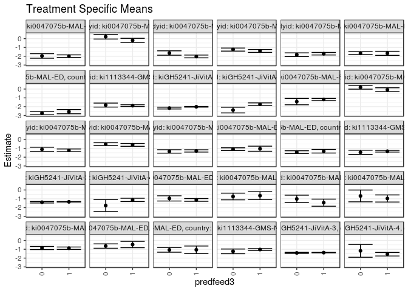

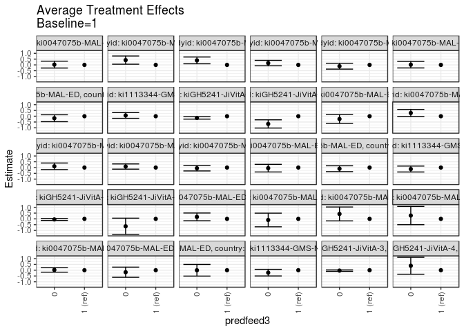

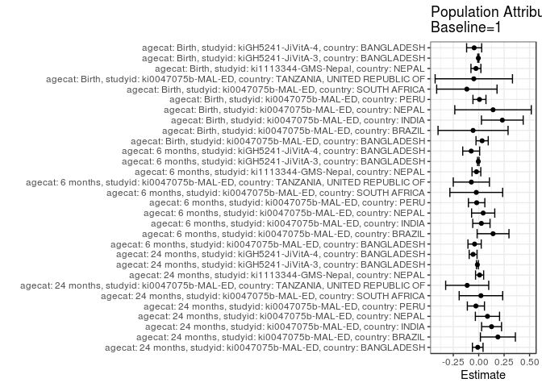

## Results Table

### Parameter: TSM

| agecat | studyid | country | intervention_level | baseline_level | estimate | ci_lower | ci_upper |
| --- | --- | --- | --- | --- | --- | --- | --- |
| Birth | ki0047075b-MAL-ED | BANGLADESH | 1 | NA | -1.1284297 | -1.2831133 | -0.9737461 |
| Birth | ki0047075b-MAL-ED | BANGLADESH | 0 | NA | -0.9564913 | -1.2521455 | -0.6608372 |
| Birth | ki0047075b-MAL-ED | BRAZIL | 1 | NA | -0.6439460 | -1.0949433 | -0.1929487 |
| Birth | ki0047075b-MAL-ED | BRAZIL | 0 | NA | -0.7398143 | -1.1191494 | -0.3604792 |
| Birth | ki0047075b-MAL-ED | INDIA | 1 | NA | -1.4397968 | -1.8436488 | -1.0359449 |
| Birth | ki0047075b-MAL-ED | INDIA | 0 | NA | -1.0131448 | -1.4372998 | -0.5889897 |
| Birth | ki0047075b-MAL-ED | NEPAL | 1 | NA | -0.9644282 | -1.3662527 | -0.5626037 |
| Birth | ki0047075b-MAL-ED | NEPAL | 0 | NA | -0.6766050 | -1.3447022 | -0.0085078 |
| Birth | ki0047075b-MAL-ED | PERU | 1 | NA | -0.8826425 | -1.0185550 | -0.7467299 |
| Birth | ki0047075b-MAL-ED | PERU | 0 | NA | -0.8574188 | -1.0319979 | -0.6828396 |
| Birth | ki0047075b-MAL-ED | SOUTH AFRICA | 1 | NA | -0.4629341 | -0.8218805 | -0.1039878 |
| Birth | ki0047075b-MAL-ED | SOUTH AFRICA | 0 | NA | -0.6373935 | -0.8856409 | -0.3891462 |
| Birth | ki0047075b-MAL-ED | TANZANIA, UNITED REPUBLIC OF | 1 | NA | -1.0603285 | -1.4838506 | -0.6368064 |
| Birth | ki0047075b-MAL-ED | TANZANIA, UNITED REPUBLIC OF | 0 | NA | -1.0655073 | -1.3343110 | -0.7967036 |
| Birth | ki1113344-GMS-Nepal | NEPAL | 1 | NA | -1.0281167 | -1.1351039 | -0.9211296 |
| Birth | ki1113344-GMS-Nepal | NEPAL | 0 | NA | -1.2395263 | -1.5060737 | -0.9729788 |
| Birth | kiGH5241-JiVitA-3 | BANGLADESH | 1 | NA | -1.3806717 | -1.4068198 | -1.3545235 |
| Birth | kiGH5241-JiVitA-3 | BANGLADESH | 0 | NA | -1.4160658 | -1.4788337 | -1.3532979 |
| Birth | kiGH5241-JiVitA-4 | BANGLADESH | 1 | NA | -1.5623716 | -1.7646655 | -1.3600777 |
| Birth | kiGH5241-JiVitA-4 | BANGLADESH | 0 | NA | -1.1781015 | -1.9049230 | -0.4512800 |
| 6 months | ki0047075b-MAL-ED | BANGLADESH | 1 | NA | -1.1842414 | -1.3096336 | -1.0588491 |
| 6 months | ki0047075b-MAL-ED | BANGLADESH | 0 | NA | -1.4225579 | -1.7838717 | -1.0612442 |
| 6 months | ki0047075b-MAL-ED | BRAZIL | 1 | NA | -0.0768465 | -0.3009884 | 0.1472954 |
| 6 months | ki0047075b-MAL-ED | BRAZIL | 0 | NA | 0.2023350 | -0.0123880 | 0.4170579 |
| 6 months | ki0047075b-MAL-ED | INDIA | 1 | NA | -1.2264398 | -1.3775187 | -1.0753609 |
| 6 months | ki0047075b-MAL-ED | INDIA | 0 | NA | -1.1190599 | -1.3594498 | -0.8786699 |
| 6 months | ki0047075b-MAL-ED | NEPAL | 1 | NA | -0.6067403 | -0.7700518 | -0.4434289 |
| 6 months | ki0047075b-MAL-ED | NEPAL | 0 | NA | -0.5192346 | -0.6742110 | -0.3642582 |
| 6 months | ki0047075b-MAL-ED | PERU | 1 | NA | -1.2947646 | -1.4246252 | -1.1649041 |
| 6 months | ki0047075b-MAL-ED | PERU | 0 | NA | -1.3530090 | -1.5478796 | -1.1581384 |
| 6 months | ki0047075b-MAL-ED | SOUTH AFRICA | 1 | NA | -1.0425524 | -1.3304932 | -0.7546117 |
| 6 months | ki0047075b-MAL-ED | SOUTH AFRICA | 0 | NA | -1.0943841 | -1.2488149 | -0.9399533 |
| 6 months | ki0047075b-MAL-ED | TANZANIA, UNITED REPUBLIC OF | 1 | NA | -1.3305665 | -1.5346295 | -1.1265035 |
| 6 months | ki0047075b-MAL-ED | TANZANIA, UNITED REPUBLIC OF | 0 | NA | -1.4306479 | -1.5852416 | -1.2760542 |
| 6 months | ki1113344-GMS-Nepal | NEPAL | 1 | NA | -1.3271807 | -1.4220627 | -1.2322986 |
| 6 months | ki1113344-GMS-Nepal | NEPAL | 0 | NA | -1.4540894 | -1.6919429 | -1.2162359 |
| 6 months | kiGH5241-JiVitA-3 | BANGLADESH | 1 | NA | -1.3429709 | -1.3721448 | -1.3137971 |
| 6 months | kiGH5241-JiVitA-3 | BANGLADESH | 0 | NA | -1.3901263 | -1.4753025 | -1.3049500 |
| 6 months | kiGH5241-JiVitA-4 | BANGLADESH | 1 | NA | -1.1254506 | -1.3123303 | -0.9385709 |
| 6 months | kiGH5241-JiVitA-4 | BANGLADESH | 0 | NA | -1.7666185 | -2.4490077 | -1.0842294 |
| 24 months | ki0047075b-MAL-ED | BANGLADESH | 1 | NA | -1.9924792 | -2.1402066 | -1.8447518 |
| 24 months | ki0047075b-MAL-ED | BANGLADESH | 0 | NA | -1.9671985 | -2.2239964 | -1.7104006 |
| 24 months | ki0047075b-MAL-ED | BRAZIL | 1 | NA | -0.2038150 | -0.4387766 | 0.0311467 |
| 24 months | ki0047075b-MAL-ED | BRAZIL | 0 | NA | 0.2110056 | -0.0516404 | 0.4736517 |
| 24 months | ki0047075b-MAL-ED | INDIA | 1 | NA | -2.0243174 | -2.1810012 | -1.8676337 |
| 24 months | ki0047075b-MAL-ED | INDIA | 0 | NA | -1.6355712 | -1.8831364 | -1.3880060 |
| 24 months | ki0047075b-MAL-ED | NEPAL | 1 | NA | -1.4013367 | -1.5659955 | -1.2366778 |
| 24 months | ki0047075b-MAL-ED | NEPAL | 0 | NA | -1.2441179 | -1.4167277 | -1.0715082 |
| 24 months | ki0047075b-MAL-ED | PERU | 1 | NA | -1.7155577 | -1.8596145 | -1.5715009 |
| 24 months | ki0047075b-MAL-ED | PERU | 0 | NA | -1.8271879 | -2.0380476 | -1.6163282 |
| 24 months | ki0047075b-MAL-ED | SOUTH AFRICA | 1 | NA | -1.6685615 | -1.8996018 | -1.4375212 |
| 24 months | ki0047075b-MAL-ED | SOUTH AFRICA | 0 | NA | -1.6483792 | -1.8149714 | -1.4817870 |
| 24 months | ki0047075b-MAL-ED | TANZANIA, UNITED REPUBLIC OF | 1 | NA | -2.5629561 | -2.8020990 | -2.3238132 |
| 24 months | ki0047075b-MAL-ED | TANZANIA, UNITED REPUBLIC OF | 0 | NA | -2.7364895 | -2.9148159 | -2.5581631 |
| 24 months | ki1113344-GMS-Nepal | NEPAL | 1 | NA | -1.8840199 | -1.9857333 | -1.7823065 |
| 24 months | ki1113344-GMS-Nepal | NEPAL | 0 | NA | -1.8170968 | -2.0439990 | -1.5901945 |
| 24 months | kiGH5241-JiVitA-3 | BANGLADESH | 1 | NA | -2.0106968 | -2.0486746 | -1.9727189 |
| 24 months | kiGH5241-JiVitA-3 | BANGLADESH | 0 | NA | -2.1573121 | -2.2598361 | -2.0547882 |
| 24 months | kiGH5241-JiVitA-4 | BANGLADESH | 1 | NA | -1.7174170 | -1.8655040 | -1.5693300 |
| 24 months | kiGH5241-JiVitA-4 | BANGLADESH | 0 | NA | -2.3833711 | -2.7062824 | -2.0604598 |

### Parameter: E(Y)

| agecat | studyid | country | intervention_level | baseline_level | estimate | ci_lower | ci_upper |
| --- | --- | --- | --- | --- | --- | --- | --- |
| Birth | ki0047075b-MAL-ED | BANGLADESH | NA | NA | -1.0949767 | -1.2319917 | -0.9579618 |
| Birth | ki0047075b-MAL-ED | BRAZIL | NA | NA | -0.6996491 | -0.9856018 | -0.4136965 |
| Birth | ki0047075b-MAL-ED | INDIA | NA | NA | -1.2075610 | -1.5261540 | -0.8889679 |
| Birth | ki0047075b-MAL-ED | NEPAL | NA | NA | -0.8234615 | -1.1896049 | -0.4573182 |
| Birth | ki0047075b-MAL-ED | PERU | NA | NA | -0.8753812 | -0.9932108 | -0.7575515 |
| Birth | ki0047075b-MAL-ED | SOUTH AFRICA | NA | NA | -0.5797000 | -0.7788298 | -0.3805702 |
| Birth | ki0047075b-MAL-ED | TANZANIA, UNITED REPUBLIC OF | NA | NA | -1.1086275 | -1.3310338 | -0.8862211 |
| Birth | ki1113344-GMS-Nepal | NEPAL | NA | NA | -1.0555240 | -1.1550843 | -0.9559638 |
| Birth | kiGH5241-JiVitA-3 | BANGLADESH | NA | NA | -1.3843216 | -1.4102231 | -1.3584201 |
| Birth | kiGH5241-JiVitA-4 | BANGLADESH | NA | NA | -1.6073276 | -1.8105798 | -1.4040753 |
| 6 months | ki0047075b-MAL-ED | BANGLADESH | NA | NA | -1.2248069 | -1.3446487 | -1.1049651 |
| 6 months | ki0047075b-MAL-ED | BRAZIL | NA | NA | 0.0641266 | -0.0913400 | 0.2195931 |
| 6 months | ki0047075b-MAL-ED | INDIA | NA | NA | -1.2002063 | -1.3275718 | -1.0728409 |
| 6 months | ki0047075b-MAL-ED | NEPAL | NA | NA | -0.5628634 | -0.6765658 | -0.4491611 |
| 6 months | ki0047075b-MAL-ED | PERU | NA | NA | -1.3153519 | -1.4229629 | -1.2077408 |
| 6 months | ki0047075b-MAL-ED | SOUTH AFRICA | NA | NA | -1.0665369 | -1.1970117 | -0.9360620 |
| 6 months | ki0047075b-MAL-ED | TANZANIA, UNITED REPUBLIC OF | NA | NA | -1.4030503 | -1.5292443 | -1.2768563 |
| 6 months | ki1113344-GMS-Nepal | NEPAL | NA | NA | -1.3499849 | -1.4387386 | -1.2612312 |
| 6 months | kiGH5241-JiVitA-3 | BANGLADESH | NA | NA | -1.3470624 | -1.3756620 | -1.3184628 |
| 6 months | kiGH5241-JiVitA-4 | BANGLADESH | NA | NA | -1.1994318 | -1.3808291 | -1.0180345 |
| 24 months | ki0047075b-MAL-ED | BANGLADESH | NA | NA | -2.0021951 | -2.1308572 | -1.8735330 |
| 24 months | ki0047075b-MAL-ED | BRAZIL | NA | NA | -0.0151974 | -0.1917967 | 0.1614019 |
| 24 months | ki0047075b-MAL-ED | INDIA | NA | NA | -1.8978960 | -2.0332143 | -1.7625777 |
| 24 months | ki0047075b-MAL-ED | NEPAL | NA | NA | -1.3153636 | -1.4359803 | -1.1947469 |
| 24 months | ki0047075b-MAL-ED | PERU | NA | NA | -1.7432323 | -1.8646545 | -1.6218102 |
| 24 months | ki0047075b-MAL-ED | SOUTH AFRICA | NA | NA | -1.6467544 | -1.7856657 | -1.5078431 |
| 24 months | ki0047075b-MAL-ED | TANZANIA, UNITED REPUBLIC OF | NA | NA | -2.6763587 | -2.8207363 | -2.5319811 |
| 24 months | ki1113344-GMS-Nepal | NEPAL | NA | NA | -1.8752995 | -1.9688053 | -1.7817937 |
| 24 months | kiGH5241-JiVitA-3 | BANGLADESH | NA | NA | -2.0239144 | -2.0607740 | -1.9870548 |
| 24 months | kiGH5241-JiVitA-4 | BANGLADESH | NA | NA | -1.7726490 | -1.9111913 | -1.6341067 |

### Parameter: ATE

| agecat | studyid | country | intervention_level | baseline_level | estimate | ci_lower | ci_upper |
| --- | --- | --- | --- | --- | --- | --- | --- |
| Birth | ki0047075b-MAL-ED | BANGLADESH | 1 | 1 | 0.0000000 | 0.0000000 | 0.0000000 |
| Birth | ki0047075b-MAL-ED | BANGLADESH | 0 | 1 | 0.1719384 | -0.1617671 | 0.5056438 |
| Birth | ki0047075b-MAL-ED | BRAZIL | 1 | 1 | 0.0000000 | 0.0000000 | 0.0000000 |
| Birth | ki0047075b-MAL-ED | BRAZIL | 0 | 1 | -0.0958683 | -0.6853719 | 0.4936353 |
| Birth | ki0047075b-MAL-ED | INDIA | 1 | 1 | 0.0000000 | 0.0000000 | 0.0000000 |
| Birth | ki0047075b-MAL-ED | INDIA | 0 | 1 | 0.4266521 | -0.1725224 | 1.0258266 |
| Birth | ki0047075b-MAL-ED | NEPAL | 1 | 1 | 0.0000000 | 0.0000000 | 0.0000000 |
| Birth | ki0047075b-MAL-ED | NEPAL | 0 | 1 | 0.2878232 | -0.4999148 | 1.0755612 |
| Birth | ki0047075b-MAL-ED | PERU | 1 | 1 | 0.0000000 | 0.0000000 | 0.0000000 |
| Birth | ki0047075b-MAL-ED | PERU | 0 | 1 | 0.0252237 | -0.1707678 | 0.2212152 |
| Birth | ki0047075b-MAL-ED | SOUTH AFRICA | 1 | 1 | 0.0000000 | 0.0000000 | 0.0000000 |
| Birth | ki0047075b-MAL-ED | SOUTH AFRICA | 0 | 1 | -0.1744594 | -0.6126604 | 0.2637415 |
| Birth | ki0047075b-MAL-ED | TANZANIA, UNITED REPUBLIC OF | 1 | 1 | 0.0000000 | 0.0000000 | 0.0000000 |
| Birth | ki0047075b-MAL-ED | TANZANIA, UNITED REPUBLIC OF | 0 | 1 | -0.0051788 | -0.5090342 | 0.4986766 |
| Birth | ki1113344-GMS-Nepal | NEPAL | 1 | 1 | 0.0000000 | 0.0000000 | 0.0000000 |
| Birth | ki1113344-GMS-Nepal | NEPAL | 0 | 1 | -0.2114095 | -0.4987287 | 0.0759096 |
| Birth | kiGH5241-JiVitA-3 | BANGLADESH | 1 | 1 | 0.0000000 | 0.0000000 | 0.0000000 |
| Birth | kiGH5241-JiVitA-3 | BANGLADESH | 0 | 1 | -0.0353941 | -0.0967298 | 0.0259416 |
| Birth | kiGH5241-JiVitA-4 | BANGLADESH | 1 | 1 | 0.0000000 | 0.0000000 | 0.0000000 |
| Birth | kiGH5241-JiVitA-4 | BANGLADESH | 0 | 1 | 0.3842701 | -0.3480352 | 1.1165754 |
| 6 months | ki0047075b-MAL-ED | BANGLADESH | 1 | 1 | 0.0000000 | 0.0000000 | 0.0000000 |
| 6 months | ki0047075b-MAL-ED | BANGLADESH | 0 | 1 | -0.2383166 | -0.6217615 | 0.1451284 |
| 6 months | ki0047075b-MAL-ED | BRAZIL | 1 | 1 | 0.0000000 | 0.0000000 | 0.0000000 |
| 6 months | ki0047075b-MAL-ED | BRAZIL | 0 | 1 | 0.2791814 | -0.0314524 | 0.5898153 |
| 6 months | ki0047075b-MAL-ED | INDIA | 1 | 1 | 0.0000000 | 0.0000000 | 0.0000000 |
| 6 months | ki0047075b-MAL-ED | INDIA | 0 | 1 | 0.1073799 | -0.1770309 | 0.3917907 |
| 6 months | ki0047075b-MAL-ED | NEPAL | 1 | 1 | 0.0000000 | 0.0000000 | 0.0000000 |
| 6 months | ki0047075b-MAL-ED | NEPAL | 0 | 1 | 0.0875057 | -0.1366183 | 0.3116296 |
| 6 months | ki0047075b-MAL-ED | PERU | 1 | 1 | 0.0000000 | 0.0000000 | 0.0000000 |
| 6 months | ki0047075b-MAL-ED | PERU | 0 | 1 | -0.0582444 | -0.2925427 | 0.1760539 |
| 6 months | ki0047075b-MAL-ED | SOUTH AFRICA | 1 | 1 | 0.0000000 | 0.0000000 | 0.0000000 |
| 6 months | ki0047075b-MAL-ED | SOUTH AFRICA | 0 | 1 | -0.0518317 | -0.3799066 | 0.2762433 |
| 6 months | ki0047075b-MAL-ED | TANZANIA, UNITED REPUBLIC OF | 1 | 1 | 0.0000000 | 0.0000000 | 0.0000000 |
| 6 months | ki0047075b-MAL-ED | TANZANIA, UNITED REPUBLIC OF | 0 | 1 | -0.1000814 | -0.3534585 | 0.1532957 |
| 6 months | ki1113344-GMS-Nepal | NEPAL | 1 | 1 | 0.0000000 | 0.0000000 | 0.0000000 |
| 6 months | ki1113344-GMS-Nepal | NEPAL | 0 | 1 | -0.1269087 | -0.3824782 | 0.1286607 |
| 6 months | kiGH5241-JiVitA-3 | BANGLADESH | 1 | 1 | 0.0000000 | 0.0000000 | 0.0000000 |
| 6 months | kiGH5241-JiVitA-3 | BANGLADESH | 0 | 1 | -0.0471553 | -0.1333141 | 0.0390035 |
| 6 months | kiGH5241-JiVitA-4 | BANGLADESH | 1 | 1 | 0.0000000 | 0.0000000 | 0.0000000 |
| 6 months | kiGH5241-JiVitA-4 | BANGLADESH | 0 | 1 | -0.6411679 | -1.3448499 | 0.0625141 |
| 24 months | ki0047075b-MAL-ED | BANGLADESH | 1 | 1 | 0.0000000 | 0.0000000 | 0.0000000 |
| 24 months | ki0047075b-MAL-ED | BANGLADESH | 0 | 1 | 0.0252807 | -0.2719976 | 0.3225590 |
| 24 months | ki0047075b-MAL-ED | BRAZIL | 1 | 1 | 0.0000000 | 0.0000000 | 0.0000000 |
| 24 months | ki0047075b-MAL-ED | BRAZIL | 0 | 1 | 0.4148206 | 0.0599129 | 0.7697283 |
| 24 months | ki0047075b-MAL-ED | INDIA | 1 | 1 | 0.0000000 | 0.0000000 | 0.0000000 |
| 24 months | ki0047075b-MAL-ED | INDIA | 0 | 1 | 0.3887462 | 0.0952843 | 0.6822082 |
| 24 months | ki0047075b-MAL-ED | NEPAL | 1 | 1 | 0.0000000 | 0.0000000 | 0.0000000 |
| 24 months | ki0047075b-MAL-ED | NEPAL | 0 | 1 | 0.1572187 | -0.0783128 | 0.3927503 |
| 24 months | ki0047075b-MAL-ED | PERU | 1 | 1 | 0.0000000 | 0.0000000 | 0.0000000 |
| 24 months | ki0047075b-MAL-ED | PERU | 0 | 1 | -0.1116302 | -0.3623694 | 0.1391090 |
| 24 months | ki0047075b-MAL-ED | SOUTH AFRICA | 1 | 1 | 0.0000000 | 0.0000000 | 0.0000000 |
| 24 months | ki0047075b-MAL-ED | SOUTH AFRICA | 0 | 1 | 0.0201823 | -0.2634040 | 0.3037687 |
| 24 months | ki0047075b-MAL-ED | TANZANIA, UNITED REPUBLIC OF | 1 | 1 | 0.0000000 | 0.0000000 | 0.0000000 |
| 24 months | ki0047075b-MAL-ED | TANZANIA, UNITED REPUBLIC OF | 0 | 1 | -0.1735334 | -0.4726255 | 0.1255587 |
| 24 months | ki1113344-GMS-Nepal | NEPAL | 1 | 1 | 0.0000000 | 0.0000000 | 0.0000000 |
| 24 months | ki1113344-GMS-Nepal | NEPAL | 0 | 1 | 0.0669231 | -0.1794625 | 0.3133088 |
| 24 months | kiGH5241-JiVitA-3 | BANGLADESH | 1 | 1 | 0.0000000 | 0.0000000 | 0.0000000 |
| 24 months | kiGH5241-JiVitA-3 | BANGLADESH | 0 | 1 | -0.1466154 | -0.2525586 | -0.0406721 |
| 24 months | kiGH5241-JiVitA-4 | BANGLADESH | 1 | 1 | 0.0000000 | 0.0000000 | 0.0000000 |
| 24 months | kiGH5241-JiVitA-4 | BANGLADESH | 0 | 1 | -0.6659541 | -1.0216773 | -0.3102309 |

### Parameter: PAR

| agecat | studyid | country | intervention_level | baseline_level | estimate | ci_lower | ci_upper |
| --- | --- | --- | --- | --- | --- | --- | --- |
| Birth | ki0047075b-MAL-ED | BANGLADESH | 1 | NA | 0.0334529 | -0.0266469 | 0.0935527 |
| Birth | ki0047075b-MAL-ED | BRAZIL | 1 | NA | -0.0557031 | -0.4000830 | 0.2886768 |
| Birth | ki0047075b-MAL-ED | INDIA | 1 | NA | 0.2322359 | 0.0269935 | 0.4374782 |
| Birth | ki0047075b-MAL-ED | NEPAL | 1 | NA | 0.1409667 | -0.2352275 | 0.5171609 |
| Birth | ki0047075b-MAL-ED | PERU | 1 | NA | 0.0072613 | -0.0567307 | 0.0712533 |
| Birth | ki0047075b-MAL-ED | SOUTH AFRICA | 1 | NA | -0.1167659 | -0.4137104 | 0.1801786 |
| Birth | ki0047075b-MAL-ED | TANZANIA, UNITED REPUBLIC OF | 1 | NA | -0.0482990 | -0.4287258 | 0.3321278 |
| Birth | ki1113344-GMS-Nepal | NEPAL | 1 | NA | -0.0274073 | -0.0762585 | 0.0214439 |
| Birth | kiGH5241-JiVitA-3 | BANGLADESH | 1 | NA | -0.0036499 | -0.0093748 | 0.0020750 |
| Birth | kiGH5241-JiVitA-4 | BANGLADESH | 1 | NA | -0.0449560 | -0.1189956 | 0.0290836 |
| 6 months | ki0047075b-MAL-ED | BANGLADESH | 1 | NA | -0.0405655 | -0.1058686 | 0.0247376 |
| 6 months | ki0047075b-MAL-ED | BRAZIL | 1 | NA | 0.1409731 | -0.0155486 | 0.2974947 |
| 6 months | ki0047075b-MAL-ED | INDIA | 1 | NA | 0.0262334 | -0.0588430 | 0.1113099 |
| 6 months | ki0047075b-MAL-ED | NEPAL | 1 | NA | 0.0438769 | -0.0700054 | 0.1577592 |
| 6 months | ki0047075b-MAL-ED | PERU | 1 | NA | -0.0205872 | -0.1013166 | 0.0601422 |
| 6 months | ki0047075b-MAL-ED | SOUTH AFRICA | 1 | NA | -0.0239844 | -0.2836322 | 0.2356633 |
| 6 months | ki0047075b-MAL-ED | TANZANIA, UNITED REPUBLIC OF | 1 | NA | -0.0724838 | -0.2504425 | 0.1054749 |
| 6 months | ki1113344-GMS-Nepal | NEPAL | 1 | NA | -0.0228042 | -0.0659980 | 0.0203895 |
| 6 months | kiGH5241-JiVitA-3 | BANGLADESH | 1 | NA | -0.0040915 | -0.0116023 | 0.0034193 |
| 6 months | kiGH5241-JiVitA-4 | BANGLADESH | 1 | NA | -0.0739812 | -0.1573554 | 0.0093930 |
| 24 months | ki0047075b-MAL-ED | BANGLADESH | 1 | NA | -0.0097159 | -0.0620331 | 0.0426013 |
| 24 months | ki0047075b-MAL-ED | BRAZIL | 1 | NA | 0.1886176 | 0.0165948 | 0.3606404 |
| 24 months | ki0047075b-MAL-ED | INDIA | 1 | NA | 0.1264214 | 0.0284458 | 0.2243970 |
| 24 months | ki0047075b-MAL-ED | NEPAL | 1 | NA | 0.0859730 | -0.0329214 | 0.2048674 |
| 24 months | ki0047075b-MAL-ED | PERU | 1 | NA | -0.0276746 | -0.1118000 | 0.0564508 |
| 24 months | ki0047075b-MAL-ED | SOUTH AFRICA | 1 | NA | 0.0218071 | -0.1921981 | 0.2358124 |
| 24 months | ki0047075b-MAL-ED | TANZANIA, UNITED REPUBLIC OF | 1 | NA | -0.1134026 | -0.3251143 | 0.0983091 |
| 24 months | ki1113344-GMS-Nepal | NEPAL | 1 | NA | 0.0087204 | -0.0311199 | 0.0485607 |
| 24 months | kiGH5241-JiVitA-3 | BANGLADESH | 1 | NA | -0.0132176 | -0.0226775 | -0.0037577 |
| 24 months | kiGH5241-JiVitA-4 | BANGLADESH | 1 | NA | -0.0552320 | -0.0939076 | -0.0165564 |